# Pratical Machine Learning: Prediction Assignment Writeup

### Author name: TK Thong

### Background

Using devices such as Jawbone Up, Nike FuelBand, and Fitbit it is now possible to collect a large amount of data about personal activity relatively inexpensively. These type of devices are part of the quantified self movement - a group of enthusiasts who take measurements about themselves regularly to improve their health, to find patterns in their behavior, or because they are tech geeks.

One thing that people regularly do is quantify how much of a particular activity they do, but they rarely quantify how well they do it. In this data set, the participants were asked to perform barbell lifts correctly and incorrectly in 5 different ways. More information is available from the website here: http://groupware.les.inf.puc-rio.br/har (see the section on the Weight Lifting Exercise Dataset).

The goal of this project is to predict the manner of performing unilateral dumbbell biceps curls based on data from accelerometers on the belt, forearm, arm, and dumbell of 6 participants. The prediction response is the “classe” variable in the training set. Five different fashions: exactly according to the specification (Class A), throwing the elbows to the front (Class B), lifting the dumbbell only halfway (Class C), lowering the dumbbell only halfway (Class D) and throwing the hips to the front (Class E). Class A corresponds to the specified execution of the exercise, while the other 4 classes correspond to common mistakes.

### Load data

We load the data set

```r
if (!file.exists("pml-training.csv")){
    download.file("https://d396qusza40orc.cloudfront.net/predmachlearn/pml-training.csv",
                  "pml-training.csv")
}
if (!file.exists("pml-testing.csv")){
    download.file("https://d396qusza40orc.cloudfront.net/predmachlearn/pml-testing.csv",
                  "pml-testing.csv")
}
trainingRawData = read.csv("pml-training.csv", na.strings = c("NA", ""))
dim(trainingRawData)
```

```
## [1] 19622   160
```

```r
testingRawData = read.csv("pml-testing.csv", na.strings=c("", "NA", "NULL"))
dim(testingRawData)
```

```
## [1]  20 160
```

The raw dataset contained 160 variables and 19622 rows of data. The test data has 20 rows of data.

## Preprocess

First perform preprocess to remove NA and reduce predictor. Variables not related to movement sensors will be removed.  
Many variables contained missing data are to be removed from the dataset. Belt, arm, dumbbell, and forearm variables that do not have any missing values in the raw dataset will be predictor variables. Finally, subset the raw dataset to include only the needed predictor variables and the classe outcome variable.

```r
set.seed(111)
trainingRawData$classe <- as.factor(trainingRawData$classe)
isNA <- sapply(trainingRawData, function (x) any(is.na(x) | x == ""))
predictor <- !isNA & grepl("belt|[^(fore)]arm|dumbbell|forearm", names(isNA))
predictVar <- names(isNA)[predictor]
allVariables <- c(predictVar, "classe")
trainingRawData <- trainingRawData[, allVariables]
dim(trainingRawData)
```

```
## [1] 19622    53
```

```r
names(trainingRawData)
```

```
##  [1] "roll_belt"            "pitch_belt"           "yaw_belt"
##  [4] "total_accel_belt"     "gyros_belt_x"         "gyros_belt_y"
##  [7] "gyros_belt_z"         "accel_belt_x"         "accel_belt_y"
## [10] "accel_belt_z"         "magnet_belt_x"        "magnet_belt_y"
## [13] "magnet_belt_z"        "roll_arm"             "pitch_arm"
## [16] "yaw_arm"              "total_accel_arm"      "gyros_arm_x"
## [19] "gyros_arm_y"          "gyros_arm_z"          "accel_arm_x"
## [22] "accel_arm_y"          "accel_arm_z"          "magnet_arm_x"
## [25] "magnet_arm_y"         "magnet_arm_z"         "roll_dumbbell"
## [28] "pitch_dumbbell"       "yaw_dumbbell"         "total_accel_dumbbell"
## [31] "gyros_dumbbell_x"     "gyros_dumbbell_y"     "gyros_dumbbell_z"
## [34] "accel_dumbbell_x"     "accel_dumbbell_y"     "accel_dumbbell_z"
## [37] "magnet_dumbbell_x"    "magnet_dumbbell_y"    "magnet_dumbbell_z"
## [40] "roll_forearm"         "pitch_forearm"        "yaw_forearm"
## [43] "total_accel_forearm"  "gyros_forearm_x"      "gyros_forearm_y"
## [46] "gyros_forearm_z"      "accel_forearm_x"      "accel_forearm_y"
## [49] "accel_forearm_z"      "magnet_forearm_x"     "magnet_forearm_y"
## [52] "magnet_forearm_z"     "classe"
```

Final dataset have 53 variables

### Split Data

Split the raw dataset into a 60% training and 40% testing dataset for cross validation.

```r
library(caret)
inTrain = createDataPartition(y=trainingRawData$classe, p=0.6, list=FALSE)
trainData = trainingRawData[inTrain, ]
testData = trainingRawData[-inTrain, ]
dim(trainData)
```

```
## [1] 11776    53
```

```r
dim(testData)
```

```
## [1] 7846   53
```

### Centering and scaling

Perform centering and scaling for all three data set.

```r
preObj <- preProcess(trainData[, predictVar], method=c("center", "scale"))
preObj
```

```
## Created from 11776 samples and 52 variables
##
## Pre-processing:
##   - centered (52)
##   - ignored (0)
##   - scaled (52)
```

```r
predTemp <- predict(preObj, trainData[, predictVar])
trainDataCS <- data.frame(classe = trainData$classe, predTemp)

predTemp <- predict(preObj, testData[, predictVar])
testDataCS <- data.frame(classe = testData$classe, predTemp)

testDataset <- predict(preObj, testingRawData[, predictVar])
```

## Analysis

Choose two models to predict the classe variable based on the remaining predictor variables, then use confusionMatrix to compare the accuracy and get the out of sample error.

### Decision Tree

First choose the rpart tree to generate models, then plot the smooth decision tree, after that run the model with testing data and finally check the accuracy and out of sample error using confusionMatrix.

```r
library(rattle)
library(rpart.plot)

modFit <- train(classe ~ ., method = "rpart", data = trainDataCS)
print(modFit$finalModel)
```

```
## n= 11776
##
## node), split, n, loss, yval, (yprob)
##       * denotes terminal node
##
##  1) root 11776 8428 A (0.28 0.19 0.17 0.16 0.18)
##    2) roll_belt< 1.041992 10759 7418 A (0.31 0.21 0.19 0.18 0.11)
##      4) pitch_forearm< -1.572599 965   11 A (0.99 0.011 0 0 0) *
##      5) pitch_forearm>=-1.572599 9794 7407 A (0.24 0.23 0.21 0.2 0.12)
##       10) magnet_dumbbell_y< 0.6633937 8243 5902 A (0.28 0.18 0.24 0.19 0.1)
##         20) roll_forearm< 0.8463014 5187 3073 A (0.41 0.18 0.18 0.17 0.056) *
##         21) roll_forearm>=0.8463014 3056 2020 C (0.074 0.17 0.34 0.23 0.18) *
##       11) magnet_dumbbell_y>=0.6633937 1551  769 B (0.03 0.5 0.045 0.23 0.19) *
##    3) roll_belt>=1.041992 1017    7 E (0.0069 0 0 0 0.99) *
```

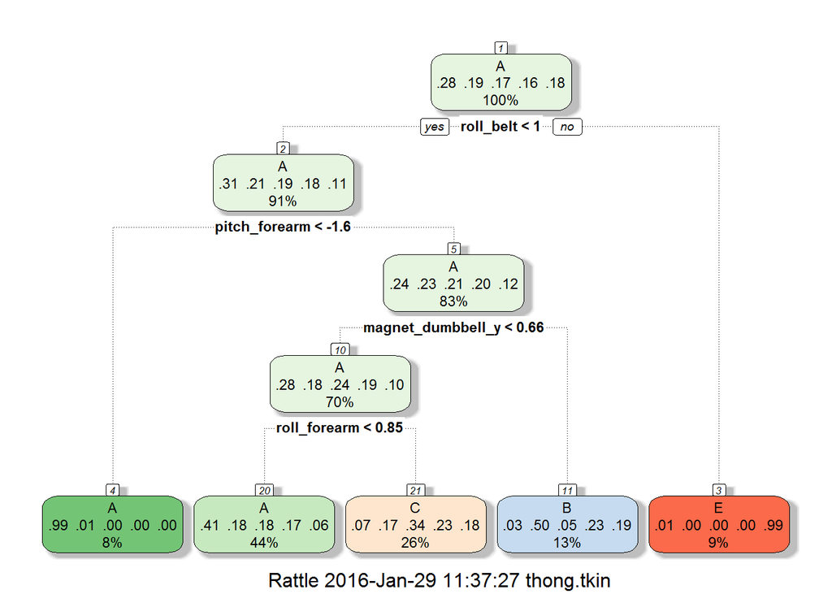

```r
fancyRpartPlot(modFit$finalModel)
```

```r
##Evaluate on test data
prediction <- predict(modFit, testDataCS)
confusionMatrix(prediction, testDataCS$classe)
```

```
## Confusion Matrix and Statistics
##
##           Reference
## Prediction    A    B    C    D    E
##          A 2018  633  645  575  233
##          B   35  504   38  215  186
##          C  172  381  685  496  402
##          D    0    0    0    0    0
##          E    7    0    0    0  621
##
## Overall Statistics
##
##                Accuracy : 0.4879
##                  95% CI : (0.4768, 0.499)
##     No Information Rate : 0.2845
##     P-Value [Acc > NIR] : < 2.2e-16
##
##                   Kappa : 0.3305
##  Mcnemar's Test P-Value : NA
##
## Statistics by Class:
##
##                      Class: A Class: B Class: C Class: D Class: E
## Sensitivity            0.9041  0.33202  0.50073   0.0000  0.43065
## Specificity            0.6284  0.92509  0.77601   1.0000  0.99891
## Pos Pred Value         0.4917  0.51534  0.32069      NaN  0.98885
## Neg Pred Value         0.9428  0.85236  0.88039   0.8361  0.88626
## Prevalence             0.2845  0.19347  0.17436   0.1639  0.18379
## Detection Rate         0.2572  0.06424  0.08731   0.0000  0.07915
## Detection Prevalence   0.5231  0.12465  0.27224   0.0000  0.08004
## Balanced Accuracy      0.7663  0.62856  0.63837   0.5000  0.71478
```

```r
cmrf<-confusionMatrix(prediction, testDataCS$classe)
```

Based on the accuracy results from the confusion matrix on the testing data, the Decision Tree’s accuracy is 48.79%, The Out of sample error is 51.21%.

### Random forest

Choose the Random Forest to generate models, after that run the model with testing data and finally check the accuracy and out of sample error using confusionMatrix.

```r
library(randomForest)

#below caret train function is extremely slow, change to randomForest()
#modFit <- train(classe ~ ., method = "rf", data = trainDataCS)
modFit <- randomForest(classe ~ ., data = trainDataCS)

modFit
```

```
##
## Call:
##  randomForest(formula = classe ~ ., data = trainDataCS)
##                Type of random forest: classification
##                      Number of trees: 500
## No. of variables tried at each split: 7
##
##         OOB estimate of  error rate: 0.58%
## Confusion matrix:
##      A    B    C    D    E  class.error
## A 3346    1    1    0    0 0.0005973716
## B   11 2260    8    0    0 0.0083369899
## C    0   11 2041    2    0 0.0063291139
## D    0    0   25 1903    2 0.0139896373
## E    0    0    3    4 2158 0.0032332564
```

```r
# Evaluate the Random Forest model on the test dataset
prediction <- predict(modFit, testDataCS)

confusionMatrix(prediction, testDataCS$classe)
```

```
## Confusion Matrix and Statistics
##
##           Reference
## Prediction    A    B    C    D    E
##          A 2232   11    0    0    0
##          B    0 1502    9    0    0
##          C    0    5 1358   21    4
##          D    0    0    1 1265    7
##          E    0    0    0    0 1431
##
## Overall Statistics
##
##                Accuracy : 0.9926
##                  95% CI : (0.9905, 0.9944)
##     No Information Rate : 0.2845
##     P-Value [Acc > NIR] : < 2.2e-16
##
##                   Kappa : 0.9906
##  Mcnemar's Test P-Value : NA
##
## Statistics by Class:
##
##                      Class: A Class: B Class: C Class: D Class: E
## Sensitivity            1.0000   0.9895   0.9927   0.9837   0.9924
## Specificity            0.9980   0.9986   0.9954   0.9988   1.0000
## Pos Pred Value         0.9951   0.9940   0.9784   0.9937   1.0000
## Neg Pred Value         1.0000   0.9975   0.9985   0.9968   0.9983
## Prevalence             0.2845   0.1935   0.1744   0.1639   0.1838
## Detection Rate         0.2845   0.1914   0.1731   0.1612   0.1824
## Detection Prevalence   0.2859   0.1926   0.1769   0.1622   0.1824
## Balanced Accuracy      0.9990   0.9940   0.9940   0.9912   0.9962
```

```r
cmrf <- confusionMatrix(prediction, testDataCS$classe)
```

Random Forest run on the Testing data has accuracy 99.26%. The Out of sample error is 0.74%.

### Variable Important

Below plot can see which variables have higher impact on the prediction based on the Random Forest model.

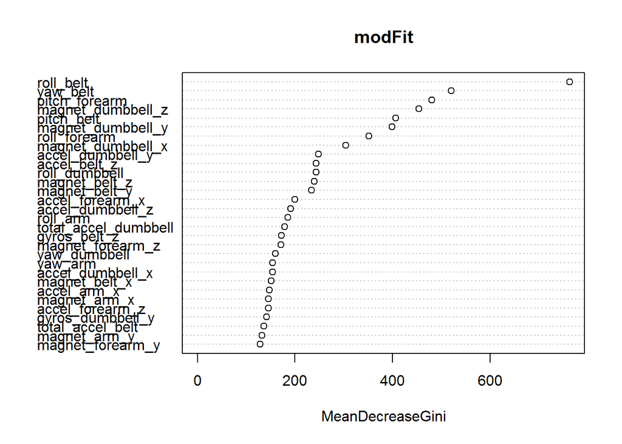

```r
varImpPlot(modFit)
```

## Conclusion

Random Forest is more accurate than Decision Tree.

Now run the Random Forest model to the testing data set.

```r
predictionclasse <- predict(modFit, testDataset)
predictionclasse
```

```
##  1  2  3  4  5  6  7  8  9 10 11 12 13 14 15 16 17 18 19 20
##  B  A  B  A  A  E  D  B  A  A  B  C  B  A  E  E  A  B  B  B
## Levels: A B C D E
```

The answers are submitted to course’s quiz for automated grading and all the answers are correct.